# Exercise 5 – Evaluation I

[Introduction to Machine Learning](https://slds-lmu.github.io/i2ml/)

## Exercise 1: Evaluating regression learners

**Learning goals**

Imagine you work for a data science start-up and sell turn-key statistical models. Based on a set of training data, you develop a regression model to predict a customer’s legal expenses from the average monthly number of indictments brought against their firm.

Due to the financial sensitivity of the situation, you opt for a very flexible learner that fits the customer’s data ($n_{train} = 50$ observations) well, and end up with a degree-21 polynomial (blue, solid). Your colleague is skeptical and argues for a much simpler linear learner (gray, dashed). Which of the models will have a lower empirical risk if standard $L2$ loss is used?

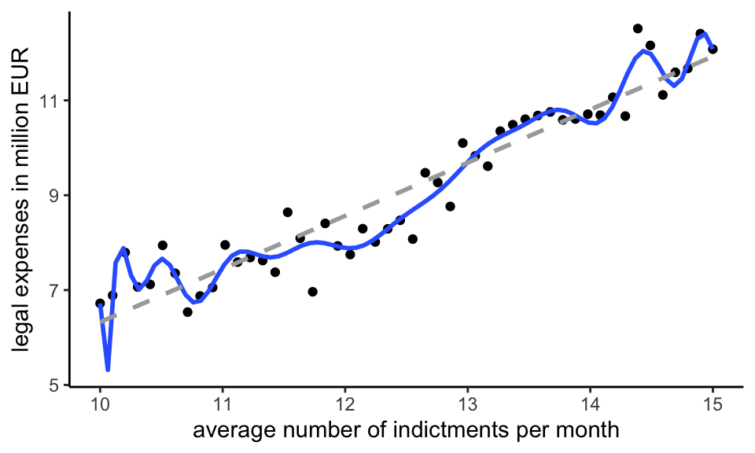

**Solution**

Since the polynomial learner clearly achieves a better fit for the training data and some observations lie rather far from the regression line, which is strongly penalized by $L2$ loss, it will have lower empirical risk than the linear learner.

Why might evaluation based on training error not be a good idea here?

**Solution**

First and foremost, evaluation on the training data is almost never a good idea. Under certain conditions the training error does tell us something about generalization ability, but for flexible learners and/or small training data it is deceptive due to optimistic bias. In this particular situation, we have few training observations and quite some points that look a little extreme. A low training error might be achieved by a learner that fits every quirk in the training data but generalizes poorly to unseen points with only slightly different distribution. Evaluation on separate test data is therefore non-negotiable.

Evaluate both learners on the following test data ($n_{test} = 10$), using

1. mean squared error (MSE), and
2. mean absolute error (MAE).

State your performance assessment and explain potential differences.

**Hint**

Use `R` or `Python` if you don’t feel like computing a degree-21 polynomial regression by hand.

**R**

```python
set.seed(123)
x_train <- seq(10, 15, length.out = 50)
y_train <- 10 + 3 * sin(0.15 * pi * x_train) + rnorm(length(x_train), sd = 0.5)
data_train <- data.frame(x = x_train, y = y_train)
set.seed(321)
x_test <- seq(10, 15, length.out = 10)
y_test <- 10 + 3 * sin(0.15 * pi * x_test) + rnorm(length(x_test), sd = 0.5)
data_test <- data.frame(x = x_test, y = y_test)
```

**Python**

```python
import numpy as np
import pandas as pd
import math
np.random.seed(43)
x_train = np.linspace(10, 15, num = 50)
y_train = 10 + 3 * np.sin(0.15 * math.pi * x_train) + \
np.random.normal(loc=0.0, scale=0.5, size= len(x_train))
data_train = pd.DataFrame({"y": y_train, "x": x_train})
np.random.seed(2238)
x_test = np.linspace(10, 15, num = 50)
y_test = 10 + 3 * np.sin(0.15 * math.pi * x_test) + \
np.random.normal(loc=0.0, scale=0.5, size= len(x_test))
data_test = pd.DataFrame({"y": y_test, "x": x_test})
```

**Solution**

**R**

```r
# define train data including outlier
set.seed(123)
x_train <- seq(10, 15, length.out = 50)
y_train <- 10 + 3 * sin(0.15 * pi * x_train) + rnorm(length(x_train), sd = 0.5)
data_train <- data.frame(x = x_train, y = y_train)

# define test data
set.seed(321)
x_test <- seq(10, 15, length.out = 10)
y_test <- 10 + 3 * sin(0.15 * pi * x_test) + rnorm(length(x_test), sd = 0.5)
data_test <- data.frame(x = x_test, y = y_test)

# train learners
polynomial_learner <- lm(y ~ poly(x, 21), data_train)
linear_learner <- lm(y ~ x, data_train)

# predict with both learners
y_polynomial <- predict(polynomial_learner, data_test)
y_lm <- predict(linear_learner, data_test)

# compute errors
abs_differences <- lapply(
  list(y_polynomial, y_lm),
  function(i) abs(data_test$y - i))
errors_mse <- sapply(abs_differences, function(i) mean(i^2))
errors_mae <- sapply(abs_differences, mean)

print(c(errors_mse, errors_mae))
```

```
[1] 0.2731046 0.3031514 0.4140316 0.3827525
```

**Python**

```python
# define train data including outlier
np.random.seed(43)
x_train = np.linspace(10, 15, num = 50)
y_train = 10 + 3 * np.sin(0.15 * math.pi * x_train) + np.random.normal(loc=0.0, scale=0.5, size= len(x_train))
# Write dictionary for pandas Data Frame to save training data
dic_train = {"y": y_train,
             "x": x_train}
data_train = pd.DataFrame(dic_train)
print(data_train.head())
```

```
          y          x
0  7.128700  10.000000
1  6.549227  10.102041
2  6.824611  10.204082
3  6.763703  10.306122
4  7.484359  10.408163
```

```python
# define test data
np.random.seed(2238)
x_test = np.linspace(10, 15, num = 50)
y_test = 10 + 3 * np.sin(0.15 * math.pi * x_test) + np.random.normal(loc=0.0, scale=0.5, size= len(x_test))
# Write dictionary for pandas Data Frame to save test data
dic_test = {"y": y_test,
            "x": x_test}
data_test = pd.DataFrame(dic_test)
print(data_test.head())
```

```
          y          x
0  6.863954  10.000000
1  5.927873  10.102041
2  6.616488  10.204082
3  7.574020  10.306122
4  6.861275  10.408163
```

```python
# train polynomial regression
poly = PolynomialFeatures(degree = 21)
x_train_poly = poly.fit_transform(x_train.reshape(-1, 1)) # reshaping necessary because single feature
x_test_poly = poly.fit_transform(x_test.reshape(-1, 1)) # reshaping necessary because single feature
poly_model = LinearRegression()
poly_model.fit(x_train_poly, y_train)

# train linear regression
lm_model = LinearRegression()
lm_model.fit(x_train.reshape(-1, 1), y_train) # reshaping necessary because single feature

# make predictions
y_poly = poly_model.predict(x_test_poly)
y_lm = lm_model.predict(x_test.reshape(-1, 1))

# compute errors
abs_differences = pd.DataFrame(np.column_stack([y_poly, y_lm])).apply(lambda y: abs(data_test.loc[:, 'y']-y)) # apply is componentwise
errors_mse = abs_differences.apply(lambda x: x**2).mean() # ** is power symbol
errors_mae = abs_differences.mean()

print("MAE for Polynomial and Linear fit:", errors_mae, sep='\n')
print("MSE for Polynomial and Linear fit:", errors_mse, sep='\n')
```

```
MAE for Polynomial and Linear fit:
0    0.436762
1    0.421898
dtype: float64
MSE for Polynomial and Linear fit:
0    0.266721
1    0.276253
dtype: float64
```

The picture is inconclusive: based on MSE, we should prefer the complex polynomial model, while MAE tells us to pick the linear one. It is important to understand that the choices of inner and outer loss functions encode our requirements and may have substantial impact on the result. Our learners differ strongly in their complexity: we have an extremely flexible polynomial and a very robust (though perhaps underfitting) linear one. If, for example, our test data contains an extreme point far from the remaining observations, the polynomial model might be able to fit it fairly well, while the LM incurs a large MSE because the distance to this point enters quadratically. The MAE, on the other hand, is more concerned with small residuals, and there, our LM fares better. Here, following the MAE assessment would signify preference for a robust model.

However, we must keep in mind that our performance evaluation is based on a single holdout split, which is not advisable in general and particularly deceptive with so little data. For different test data we quickly get in situations where the polynomial has both worse MSE and MAE – after all, slapping a learner with 21 + 1 learnable parameters on a 50-points data set should strike you as a rather bad idea.

Take-home message: the choice of our performance metric matters, and making decisions based on a single train-test split is risky in many data settings.

## Exercise 2: Importance of train-test split

**Learning goals**

We consider the `BostonHousing` data for which we would like to predict the nitric oxides concentration (`nox`) from the distance to a number of firms (`dis`).

**R**

```python
# R code
library(mlbench)
data(BostonHousing)
data_pollution <- data.frame(dis = BostonHousing$dis, nox = BostonHousing$nox)
data_pollution <- data_pollution[order(data_pollution$dis), ]
head(data_pollution)

## dis nox
## 373 1.1296 0.668
## 375 1.1370 0.668
## 372 1.1691 0.631
## 374 1.1742 0.668
## 407 1.1781 0.659
## 371 1.2024 0.631
```

**Python**

```python
import numpy as np
import pandas as pd
data_url = "http://lib.stat.cmu.edu/datasets/boston"
raw_df = pd.read_csv(data_url, sep="\s+", skiprows=22, header=None)
data = np.hstack([raw_df.values[::2, :], raw_df.values[1::2, :2]])
boston = pd.DataFrame(data[:,np.r_[4,7]], columns= ["NOX", "DIS"])
boston = boston.sort_values("DIS")
boston.reset_index(drop = True, inplace = True)
```

1. Use the first ten observations as training data to compute a linear model and evaluate the performance of your learner on the remaining data using MSE.

**Solution**

Get the data, define a task and corresponding train-test split, and predict with trained model:

**R**

```r
# get data
library(mlbench)
data(BostonHousing)
data_pollution <- data.frame(dis = BostonHousing$dis, nox = BostonHousing$nox)
data_pollution <- data_pollution[order(data_pollution$dis), ]
head(data_pollution)

# define task and train-test split
library(mlr3)
task <- mlr3::TaskRegr$new("pollution", backend = data_pollution, target = "nox")
train_set = 1:10
test_set = setdiff(seq_len(task$nrow), train_set)

# train linear learner
library(mlr3learners)
learner <- mlr3::lrn("regr.lm")
learner$train(task, row_ids = train_set)

# predict on test data
predictions <- learner$predict(task, row_ids = test_set)
predictions$score(mlr3::msr("regr.mse"))
```

A data.frame: 6 x 2

|  | dis <dbl> | nox <dbl> |
| --- | --- | --- |
| 373 | 1.1296 | 0.668 |
| 375 | 1.1370 | 0.668 |
| 372 | 1.1691 | 0.631 |
| 374 | 1.1742 | 0.668 |
| 407 | 1.1781 | 0.659 |
| 371 | 1.2024 | 0.631 |

**regr.mse:** 1.52451196592771

**Python**

```python
# boston housing from original source
data_url = "http://lib.stat.cmu.edu/datasets/boston"
raw_df = pd.read_csv(data_url, sep="\s+", skiprows=22, header=None)
data = np.hstack([raw_df.values[::2, :], raw_df.values[1::2, :2]])
boston = pd.DataFrame(data[:,np.r_[4,7]], columns= ["NOX", "DIS"])
boston = boston.sort_values("DIS") # sort for "DIS", does not reset index
boston.reset_index(drop = True, inplace = True)

# load_boston() deprecated, but still functional in our sklearn version
# boston_dataset = load_boston()
# boston = pd.DataFrame(boston_dataset.data, columns=boston_dataset.feature_names).loc[:, ["DIS", "NOX"]]

boston.head()
```

|  | NOX | DIS |
| --- | --- | --- |
| 0 | 0.668 | 1.1296 |
| 1 | 0.668 | 1.1370 |
| 2 | 0.631 | 1.1691 |
| 3 | 0.668 | 1.1742 |
| 4 | 0.659 | 1.1781 |

2. What might be disadvantageous about the train-test split in a)?

**Solution**

We have chosen the first ten observations from a data set that is ordered by feature value, which is not a good idea because this is not a random sample and covers only a particular area of the feature space. Consequently, we obtain a pretty high test MSE (relatively speaking – we will see in the next exercise which error values we can usually expect for this task). Looking at the data, this gives us a steeply declining regression line that does not reflect the overall data situation. Also, a training set of ten points is pretty small and will likely lead to poor generalization.

3. Now, sample your training observations from the data set at random. Use a share of 0.1 through 0.9, in 0.1 steps, of observations for training and repeat this procedure ten times. Afterwards, plot the resulting test errors (in terms of MSE) in a suitable manner.

**Hint**

**R**

**Python**

`from sklearn.model_selection import train_test_split` is a convenient function for splitting data. It has an optional parameter `random_state`, which can be used to split the data randomly in each iteration.

**Solution**

We repeat the above procedure for different train-test splits like so:

**R**

```r
# define train-test splits
repetitions <- 1:10
split_ratios <- seq(0.1, 0.9, by = 0.1)

# create resampling objects with holdout strategy, using lapply for efficient computation
split_strategies <- lapply(split_ratios, function(i) mlr3::rsmp("holdout", ratio = i))

# train linear learners and predict in one step (remember to set a seed)
set.seed(123)
results <- list()
for (i in repetitions) {
  results[[i]] <- lapply(split_strategies, function(i) mlr3::resample(task, learner, i))
}
```

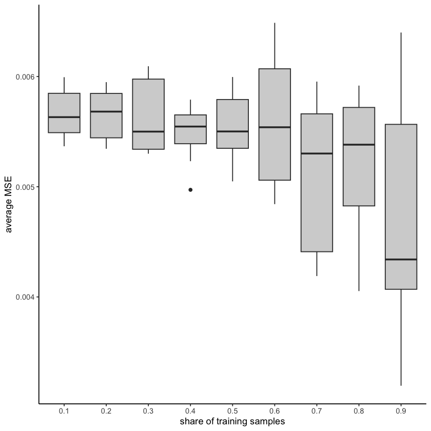

```r
# plot errors vs split ratio
library(ggplot2)
ggplot(errors_df_long, aes(x = as.factor(split_ratios), y = mse)) +
  geom_boxplot(fill = "lightgray") +
  theme_classic() +
  labs(x = "share of training samples", y = "average MSE")
```

**Python**

```python
split_ratio = np.linspace(0.1, 0.9, num = 9)

result = pd.DataFrame()
for i in range(10):
    err = []
    for split in split_ratio:
        X_train, X_test, y_train, y_test = train_test_split(dis, nox, train_size = split, random_state=i+10)
        lm_boston.fit(X = X_train, y = y_train)
        pred = lm_boston.predict(X_test)
        err.append(mean_squared_error(y_test, pred))
    result[i] = err

errors = result.transpose()
errors.columns = ["0.1", "0.2", "0.3", "0.4", "0.5", "0.6", "0.7", "0.8", "0.9"]
```

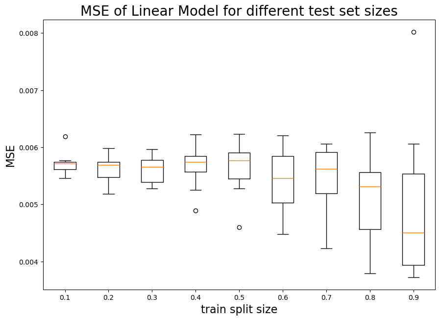

```python
# plot your errors
# instantiate plot
fig = plt.figure(figsize =(8, 5.5))
# Creating axes instance
ax = fig.add_axes([0, 0, 1, 1])
# Creating plot
bp = ax.boxplot(errors)
# x-axis labels
ax.set_xticklabels(["0.1", "0.2", "0.3", "0.4", "0.5", "0.6", "0.7", "0.8", "0.9"])
# Adding title
plt.title("MSE of Linear Model for different test set sizes", size=20)
plt.xlabel('train split size', size=16)
plt.ylabel('MSE', size=16)
# show plot
plt.show()
```

4. Interpret the findings from c).

**Solution**

From the experiment in c) we can derive two conclusions:

1. A smaller training set tends to produce higher estimated generalization errors.
2. A larger training set, at the expense of test set size, will cause high variance in the individual generalization error estimates.